# Working with and Visualizing Data in R

SMUREU Data Science Bootcamp

# Working with and Visualizing Data in R

In this notebook we will use R to:

- work with tabular data
- create new columns
- filter and sort data
- build a simple scoring model
- create visualizations
- explore ACS-style county data
- merge an additional parks dataset

```r
library(tidyverse)
```

# Part 1: Apartment Hunting

Let’s start with a dataset that is easy to understand.

Suppose you are looking for an apartment near campus.

Different apartments have different:

- rent
- size
- distance
- ratings
- pet policies

How could we use data to compare them?

```r
apts <- tibble(
  Apartment = c(
    "Mockingbird Flats",
    "Highland House",
    "Campus View",
    "The Village",
    "Oak Lawn Lofts",
    "Greenville Commons",
    "Mustang Station",
    "The Hidden Gem"
  ),
  Rent = c(950, 1450, 1100, 1700, 2100, 1250, 800, 1350),
  Bedrooms = c(1, 2, 1, 3, 2, 2, 1, 2),
  Bathrooms = c(1, 2, 1, 2, 2, 1, 1, 2),
  Sqft = c(550, 980, 620, 1400, 1150, 870, 450, 760),
  Distance = c(0.4, 1.8, 0.2, 3.5, 2.2, 1.1, 0.1, 0.9),
  Rating = c(3.8, 4.6, 3.2, 4.9, 4.7, 4.1, 2.9, 4.8),
  pets_allowed = c(
    "cat only",
    "dog and cat",
    "no",
    "all pets",
    "dog and cat",
    "cat only",
    "no",
    "all pets"
  )
)

apts
```

| Apartment | Rent | Bedrooms | Bathrooms | Sqft | Distance | Rating | pets_allowed |
| --- | --- | --- | --- | --- | --- | --- | --- |
| Mockingbird Flats | 950 | 1 | 1 | 550 | 0.4 | 3.8 | cat only |
| Highland House | 1450 | 2 | 2 | 980 | 1.8 | 4.6 | dog and cat |
| Campus View | 1100 | 1 | 1 | 620 | 0.2 | 3.2 | no |
| The Village | 1700 | 3 | 2 | 1400 | 3.5 | 4.9 | all pets |
| Oak Lawn Lofts | 2100 | 2 | 2 | 1150 | 2.2 | 4.7 | dog and cat |
| Greenville Commons | 1250 | 2 | 1 | 870 | 1.1 | 4.1 | cat only |
| Mustang Station | 800 | 1 | 1 | 450 | 0.1 | 2.9 | no |
| The Hidden Gem | 1350 | 2 | 2 | 760 | 0.9 | 4.8 | all pets |

## Question 1: Which apartment is cheapest?

```r
apts |>
  arrange(Rent)
```

| Apartment | Rent | Bedrooms | Bathrooms | Sqft | Distance | Rating | pets_allowed |
| --- | --- | --- | --- | --- | --- | --- | --- |
| Mustang Station | 800 | 1 | 1 | 450 | 0.1 | 2.9 | no |
| Mockingbird Flats | 950 | 1 | 1 | 550 | 0.4 | 3.8 | cat only |
| Campus View | 1100 | 1 | 1 | 620 | 0.2 | 3.2 | no |
| Greenville Commons | 1250 | 2 | 1 | 870 | 1.1 | 4.1 | cat only |
| The Hidden Gem | 1350 | 2 | 2 | 760 | 0.9 | 4.8 | all pets |
| Highland House | 1450 | 2 | 2 | 980 | 1.8 | 4.6 | dog and cat |
| The Village | 1700 | 3 | 2 | 1400 | 3.5 | 4.9 | all pets |
| Oak Lawn Lofts | 2100 | 2 | 2 | 1150 | 2.2 | 4.7 | dog and cat |

## Question 2: Which apartment gives the most space per dollar?

```r
apts <- apts |>
  mutate(sqft_per_dollar = Sqft / Rent)

apts |>
  arrange(desc(sqft_per_dollar))
```

| Apartment | Rent | Bedrooms | Bathrooms | Sqft | Distance | Rating | pets_allowed | sqft_per_dollar |
| --- | --- | --- | --- | --- | --- | --- | --- | --- |
| The Village | 1700 | 3 | 2 | 1400 | 3.5 | 4.9 | all pets | 0.8235294 |
| Greenville Commons | 1250 | 2 | 1 | 870 | 1.1 | 4.1 | cat only | 0.6960000 |
| Highland House | 1450 | 2 | 2 | 980 | 1.8 | 4.6 | dog and cat | 0.6758621 |
| Mockingbird Flats | 950 | 1 | 1 | 550 | 0.4 | 3.8 | cat only | 0.5789474 |
| Campus View | 1100 | 1 | 1 | 620 | 0.2 | 3.2 | no | 0.5636364 |
| The Hidden Gem | 1350 | 2 | 2 | 760 | 0.9 | 4.8 | all pets | 0.5629630 |
| Mustang Station | 800 | 1 | 1 | 450 | 0.1 | 2.9 | no | 0.5625000 |
| Oak Lawn Lofts | 2100 | 2 | 2 | 1150 | 2.2 | 4.7 | dog and cat | 0.5476190 |

Would everyone agree this is the best apartment?

What is missing from this comparison?

## Question 3: Which apartments fit a student’s needs?

Suppose we want at least 2 bedrooms and rent below 1500.

```r
apts |>
  filter(Bedrooms >= 2, Rent < 1500)
```

| Apartment | Rent | Bedrooms | Bathrooms | Sqft | Distance | Rating | pets_allowed | sqft_per_dollar |
| --- | --- | --- | --- | --- | --- | --- | --- | --- |
| Highland House | 1450 | 2 | 2 | 980 | 1.8 | 4.6 | dog and cat | 0.6758621 |
| Greenville Commons | 1250 | 2 | 1 | 870 | 1.1 | 4.1 | cat only | 0.6960000 |
| The Hidden Gem | 1350 | 2 | 2 | 760 | 0.9 | 4.8 | all pets | 0.5629630 |

# Building a Simple Scoring Model

Now let’s build a rough score.

This is not the correct answer.

It is one possible model.

```r
apts <- apts |>
  mutate(
    space_score = (Bedrooms + Bathrooms) * Sqft,
    value_score = space_score / Rent
  )
```

Smaller distances should receive larger scores, so we use the inverse of distance.

```r
apts <- apts |>
  mutate(
    distance_score = 1 / Distance,
    final_score = value_score * distance_score * Rating
  )

apts |>
  select(Apartment, Rent, Sqft, Distance, Rating, pets_allowed, final_score) |>
  arrange(desc(final_score))
```

| Apartment | Rent | Sqft | Distance | Rating | pets_allowed | final_score |
| --- | --- | --- | --- | --- | --- | --- |
| Mustang Station | 800 | 450 | 0.1 | 2.9 | no | 32.625000 |
| Campus View | 1100 | 620 | 0.2 | 3.2 | no | 18.036364 |
| The Hidden Gem | 1350 | 760 | 0.9 | 4.8 | all pets | 12.009877 |
| Mockingbird Flats | 950 | 550 | 0.4 | 3.8 | cat only | 11.000000 |
| Greenville Commons | 1250 | 870 | 1.1 | 4.1 | cat only | 7.782545 |
| Highland House | 1450 | 980 | 1.8 | 4.6 | dog and cat | 6.908812 |
| The Village | 1700 | 1400 | 3.5 | 4.9 | all pets | 5.764706 |
| Oak Lawn Lofts | 2100 | 1150 | 2.2 | 4.7 | dog and cat | 4.679654 |

## Discussion

- Do you trust this ranking?
- What variables did we ignore?
- Should pets matter?
- Should distance matter more or less?
- What would you change?

# Visualizing Apartment Data

## Rent by Apartment

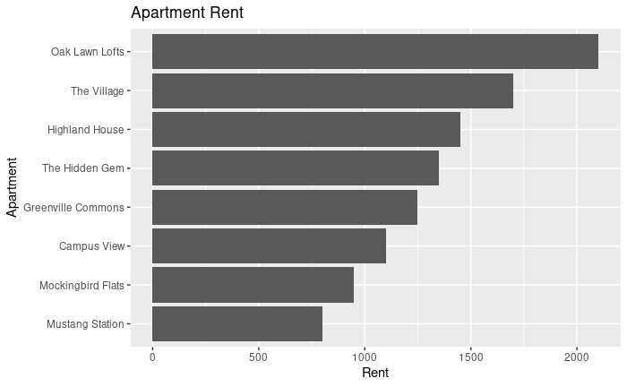

```r
ggplot(apts, aes(x = reorder(Apartment, Rent), y = Rent)) +
  geom_col() +
  coord_flip() +
  labs(
    title = "Apartment Rent",
    x = "Apartment",
    y = "Rent"
  )
```

## Rent vs Rating

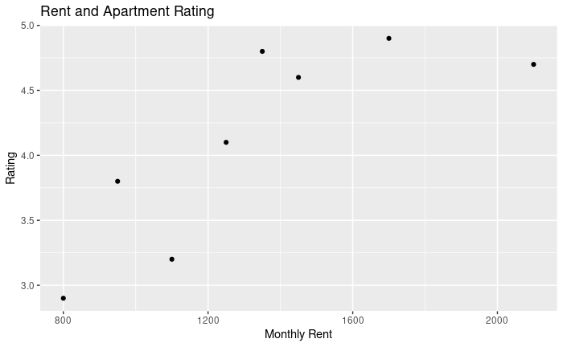

```r
ggplot(apts, aes(x = Rent, y = Rating, label = Apartment)) +
  geom_point() +
  labs(
    title = "Rent and Apartment Rating",
    x = "Monthly Rent",
    y = "Rating"
  )
```

## Score by Apartment

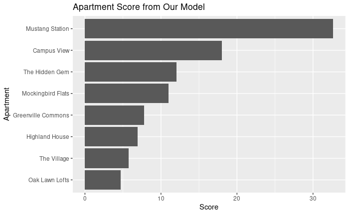

```r
ggplot(apts, aes(x = reorder(Apartment, final_score), y = final_score)) +
  geom_col() +
  coord_flip() +
  labs(
    title = "Apartment Score from Our Model",
    x = "Apartment",
    y = "Score"
  )
```

# Part 2: Working with ACS Data

Now let’s move from a toy dataset to a real public-interest dataset.

```r
acs <- read_csv("data/texas_ACS_2024_sample.csv", show_col_types = FALSE)
acs |> glimpse()
```

```
Rows: 254
Columns: 11
$ ...1                                                                                 <dbl> 0, 1, 2, 3, 4, 5, 6, 7, 8…
$ geoid                                                                                <chr> "05000US48001", "05000US4…
$ name                                                                                 <chr> "Anderson County, TX", "A…
$ `Total Population`                                                                   <dbl> 58439, 18610, 87275, 2487…
$ `Population 16 years and over in labor force`                                        <dbl> 22510, 8947, 39781, 10758…
$ `Population 25 years and over with Bachelors Degree or higher`                       <dbl> 6511, 1991, 10322, 5602, …
$ `Population 16 and over with income in the past 12 months below poverty level`       <dbl> 5822, 2030, 9084, 2755, 6…
$ `Households with Internet Subscription`                                              <dbl> 15509, 6116, 29340, 11209…
$ `Total Population in Renter Occupied Housing`                                        <dbl> 13242, 3388, 27934, 5005,…
$ `Median Household Income in the Past 12 Months (In 2024 Inflation-adjusted Dollars)` <dbl> 62068, 72242, 60960, 6946…
$ `Total Population in Owner Occupied Housing`                                         <dbl> 34828, 15022, 55932, 1960…
```

# Rename Columns

Real datasets often have long column names.

Let’s rename them for readability.

```r
acs <- acs |>
  rename(
    county = name,
    population = `Total Population`,
    labor_force = `Population 16 years and over in labor force`,
    bachelors_degree = `Population 25 years and over with Bachelors Degree or higher`,
    poverty_population = `Population 16 and over with income in the past 12 months below poverty level`,
    internet_households = `Households with Internet Subscription`,
    renters = `Total Population in Renter Occupied Housing`,
    median_income = `Median Household Income in the Past 12 Months (In 2024 Inflation-adjusted Dollars)`,
    owners = `Total Population in Owner Occupied Housing`
  ) |>
  mutate(
    county_name = str_remove(county, ", TX"),
    county_fips = str_sub(geoid, -5)
  )

acs |> head()
```

| ...1 | geoid | county | population | labor_force | bachelors_degree | poverty_population | internet_households | renters | median_income | owners | county_name | county_fips |
| --- | --- | --- | --- | --- | --- | --- | --- | --- | --- | --- | --- | --- |
| 0 | 05000US48001 | Anderson County, TX | 58439 | 22510 | 6511 | 5822 | 15509 | 13242 | 62068 | 34828 | Anderson County | 48001 |
| 1 | 05000US48003 | Andrews County, TX | 18610 | 8947 | 1991 | 2030 | 6116 | 3388 | 72242 | 15022 | Andrews County | 48003 |
| 2 | 05000US48005 | Angelina County, TX | 87275 | 39781 | 10322 | 9084 | 29340 | 27934 | 60960 | 55932 | Angelina County | 48005 |
| 3 | 05000US48007 | Aransas County, TX | 24876 | 10758 | 5602 | 2755 | 11209 | 5005 | 69466 | 19600 | Aransas County | 48007 |
| 4 | 05000US48009 | Archer County, TX | 8867 | 4263 | 1608 | 626 | 3069 | 1226 | 72159 | 7572 | Archer County | 48009 |
| 5 | 05000US48011 | Armstrong County, TX | 1822 | 887 | 353 | 72 | 713 | 385 | 72750 | 1386 | Armstrong County | 48011 |

# Looking Beyond Totals

Raw totals often tell us where the largest counties are.

```r
acs |>
  arrange(desc(population)) |>
  select(county, population) |>
  head(10)
```

| county | population |
| --- | --- |
| Harris County, TX | 4838303 |
| Dallas County, TX | 2621179 |
| Tarrant County, TX | 2167390 |
| Bexar County, TX | 2067341 |
| Travis County, TX | 1330015 |
| Collin County, TX | 1163337 |
| Denton County, TX | 979561 |
| Fort Bend County, TX | 893767 |
| Hidalgo County, TX | 891977 |
| El Paso County, TX | 870779 |

Rates often tell us something different.

The rates below are simplified educational examples. In real ACS work, pay close attention to denominators.

```r
acs <- acs |>
  mutate(
    poverty_rate = poverty_population / labor_force,
    bachelors_rate = bachelors_degree / population,
    internet_rate = internet_households / (owners + renters),
    renter_rate = renters / (owners + renters)
  )

acs |>
  select(county, poverty_rate, bachelors_rate, internet_rate, renter_rate) |>
  head()
```

| county | poverty_rate | bachelors_rate | internet_rate | renter_rate |
| --- | --- | --- | --- | --- |
| Anderson County, TX | 0.25864060 | 0.1114153 | 0.3226337 | 0.2754733 |
| Andrews County, TX | 0.22689170 | 0.1069855 | 0.3322108 | 0.1840304 |
| Angelina County, TX | 0.22835022 | 0.1182698 | 0.3498438 | 0.3330790 |
| Aransas County, TX | 0.25608849 | 0.2251970 | 0.4555578 | 0.2034139 |
| Archer County, TX | 0.14684494 | 0.1813466 | 0.3488293 | 0.1393499 |
| Armstrong County, TX | 0.08117249 | 0.1937431 | 0.4025974 | 0.2173913 |

# Visualizing ACS Data

## Income and Education

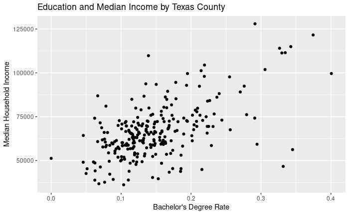

```r
ggplot(acs, aes(x = bachelors_rate, y = median_income)) +
  geom_point() +
  labs(
    title = "Education and Median Income by Texas County",
    x = "Bachelor's Degree Rate",
    y = "Median Household Income"
  )
```

## Poverty and Internet Access

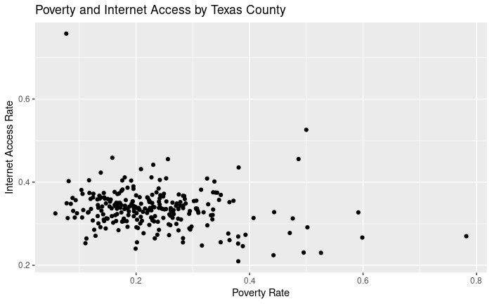

```r
ggplot(acs, aes(x = poverty_rate, y = internet_rate)) +
  geom_point() +
  labs(
    title = "Poverty and Internet Access by Texas County",
    x = "Poverty Rate",
    y = "Internet Access Rate"
  )
```

# Finding Unusual Counties

These thresholds are chosen simply to help us find unusual counties.

```r
acs |>
  filter(median_income > 80000, bachelors_rate < 0.20) |>
  select(county, median_income, bachelors_rate, poverty_rate)
```

| county | median_income | bachelors_rate | poverty_rate |
| --- | --- | --- | --- |
| Bastrop County, TX | 86226 | 0.16321705 | 0.14197615 |
| Carson County, TX | 85231 | 0.17841751 | 0.12057932 |
| Chambers County, TX | 109804 | 0.13907336 | 0.16479474 |
| Clay County, TX | 80114 | 0.16522153 | 0.13777268 |
| Crockett County, TX | 81022 | 0.07831325 | 0.18494624 |
| Ellis County, TX | 99595 | 0.19490524 | 0.09187092 |
| Johnson County, TX | 84859 | 0.16533485 | 0.14750991 |
| Kaufman County, TX | 89485 | 0.16654307 | 0.12843545 |
| Lampasas County, TX | 81736 | 0.17213295 | 0.16851574 |
| Martin County, TX | 93734 | 0.13530088 | 0.13229572 |

[output cut: 7 more lines]

# Part 3: Merging State Parks Data

Now let’s bring in a second dataset.

```r
parks <- read_csv("data/texas_state_parks_by_county.csv", show_col_types = FALSE)

parks |> head()
```

| geoid | county_name | state_park_count |
| --- | --- | --- |
| 05000US48007 | Aransas | 1 |
| 05000US48015 | Austin | 1 |
| 05000US48019 | Bandera | 3 |
| 05000US48021 | Bastrop | 2 |
| 05000US48029 | Bexar | 1 |
| 05000US48031 | Blanco | 2 |

```r
acs_parks <- acs |>
  left_join(parks, by = c("geoid" = "geoid")) |>
  mutate(state_park_count = replace_na(state_park_count, 0))

acs_parks |>
  select(county, state_park_count, median_income, poverty_rate) |>
  arrange(desc(state_park_count)) |>
  head(10)
```

| county | state_park_count | median_income | poverty_rate |
| --- | --- | --- | --- |
| Burnet County, TX | 4 | 78732 | 0.11781102 |
| Bandera County, TX | 3 | 75813 | 0.23970402 |
| Kendall County, TX | 3 | 114962 | 0.07757477 |
| Presidio County, TX | 3 | 43802 | 0.44329502 |
| Bastrop County, TX | 2 | 86226 | 0.14197615 |
| Blanco County, TX | 2 | 92425 | 0.14304791 |
| Brewster County, TX | 2 | 56212 | 0.15810277 |
| Comal County, TX | 2 | 101889 | 0.10562317 |
| Edwards County, TX | 2 | 40313 | 0.44216418 |
| El Paso County, TX | 2 | 59806 | 0.26435537 |

## Do counties with more parks have higher income?

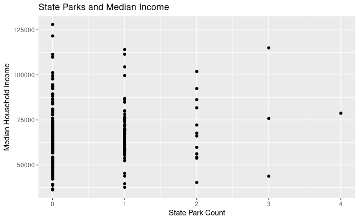

```r
ggplot(acs_parks, aes(x = state_park_count, y = median_income)) +
  geom_point() +
  labs(
    title = "State Parks and Median Income",
    x = "State Park Count",
    y = "Median Household Income"
  )
```

If a relationship exists, does that mean parks cause income?

# Mini Challenge

Choose one of the following.

## Starter

Find the top 10 counties by one variable.

## Intermediate

Create a scatter plot comparing two variables.

## Challenge

Merge parks with ACS data and investigate whether parks seem related to another county-level variable.

## Open-Ended

Find one pattern that surprised you and explain what you think might be happening.

# AI Assistant Checkpoint

Try asking an AI assistant:

- “What does this plot suggest?”
- “What are three possible explanations for this pattern?”
- “Can you find evidence in the data that supports or contradicts this explanation?”
- “How could this visualization be improved?”